# Machine Learning Lab 1

### S Shyam Sundaram 19BCE1560

# Exercise 1- Numpy

```python
import numpy as np
```

```python
arr1 = np.array([1,2,3,4,5,6])
print("1D array: ", arr1)
arr2 = np.array([[1,2,3],[4,5,6],[7,8,9]])
print("2D array: ", "\n",arr2)
```

```
1D array:  [1 2 3 4 5 6]
2D array:
 [[1 2 3]
 [4 5 6]
 [7 8 9]]
```

```python
# Creating a rank 1 Array
arr = np.array([1, 2, 3])
print("Array with Rank 1: \n",arr)
```

```
Array with Rank 1:
 [1 2 3]
```

```python
# Creating a rank 2 Array
arr = np.array([[1, 2, 3],
                [4, 5, 6]])
print("Array with Rank 2: \n", arr)
```

```
Array with Rank 2:
 [[1 2 3]
 [4 5 6]]
```

```python
# Creating an array from tuple
arr = np.array((1, 3, 2))
print("\nArray created using "
      "passed tuple:\n", arr)
```

```
Array created using passed tuple:
 [1 3 2]
```

## Understanding attributes of arrays

```python
print("About arr2:")
print("Type\t\t:" ,type(arr2))
print("Datatype\t:",arr2.dtype)
print("Shape\t\t:", arr2.shape)
print("Size\t\t:",arr2.size)
print("itemsize\t:",arr2.itemsize)
print("No. of dim\t:",arr2.ndim)
print("No. of bytes\t:", arr2.nbytes)
```

```
About arr2:
Type		: <class 'numpy.ndarray'>
Datatype	: int32
Shape		: (3, 3)
Size		: 9
itemsize	: 4
No. of dim	: 2
No. of bytes	: 36
```

## Special Arrays

```python
arr3 = np.zeros((5,2), dtype=int)
arr4 = np.ones((3,4),dtype=float)
arr5 = np.eye(4,3)
arr6 = np.random.rand(3,2)
arr7 = np.random.randint(7,size=(2,6))
print("Zero Array \t:\n",arr3)
print("Arrays with unit values\t:\n",arr4)
print("Identity matrix\t:\n",arr5)
print("Random array\t\n",arr6)
print("Random integer array\t:\n" , arr7)
```

```
Zero Array 	:
 [[0 0]
 [0 0]
 [0 0]
 [0 0]
 [0 0]]
Arrays with unit values	:
 [[1. 1. 1. 1.]
 [1. 1. 1. 1.]
 [1. 1. 1. 1.]]
Identity matrix	:
 [[1. 0. 0.]
 [0. 1. 0.]
 [0. 0. 1.]
 [0. 0. 0.]]
Random array
 [[0.78050112 0.94526287]
 [0.90809064 0.48067856]
 [0.77292278 0.71222528]]
Random integer array	:
 [[5 3 6 1 2 1]
 [3 4 3 4 3 0]]
```

## Various ways of creating arrays

```python
#Using 'arange'
arr8 = np.arange(1,10,3)
print("Array created with arange: \t\n",arr8)
```

```
Array created with arange:
 [1 4 7]
```

```python
#Using linspace
arr9 = np.linspace(1,10,50)
print("Array created using linspace requesting 50 elements within 1 to 10:\t\n",arr9)
```

```
Array created using linspace requesting 50 elements within 1 to 10:
 [ 1.          1.18367347  1.36734694  1.55102041  1.73469388  1.91836735
  2.10204082  2.28571429  2.46938776  2.65306122  2.83673469  3.02040816
  3.20408163  3.3877551   3.57142857  3.75510204  3.93877551  4.12244898
  4.30612245  4.48979592  4.67346939  4.85714286  5.04081633  5.2244898
  5.40816327  5.59183673  5.7755102   5.95918367  6.14285714  6.32653061
  6.51020408  6.69387755  6.87755102  7.06122449  7.24489796  7.42857143
  7.6122449   7.79591837  7.97959184  8.16326531  8.34693878  8.53061224
  8.71428571  8.89795918  9.08163265  9.26530612  9.44897959  9.63265306
  9.81632653 10.        ]
```

## Slicing

```python
arr10 = np.array([[1,2,3,4,5],[6,7,8,9,10],[11,12,13,14,15],[16,17,18,19,20]])
print(arr10)
print("Row 2:",arr10[1,:])
print("Column 2:",arr10[:,3])
print("Elements 7,8,12,13 :\n", arr10[1:3,1:3])
print("All elements: \n",arr10[::])
print("Strides:\n",arr10[0::2,1:3])
```

```
[[ 1  2  3  4  5]
 [ 6  7  8  9 10]
 [11 12 13 14 15]
 [16 17 18 19 20]]
Row 2: [ 6  7  8  9 10]
Column 2: [ 4  9 14 19]
Elements 7,8,12,13 :
 [[ 7  8]
 [12 13]]
All elements:
 [[ 1  2  3  4  5]
 [ 6  7  8  9 10]
 [11 12 13 14 15]
 [16 17 18 19 20]]
Strides:
 [[ 2  3]
 [12 13]]
```

## Masking

```python
arr11 = np.array([1,2,3,4,5,6,7,8,9])
mask = np.array([0,1,1,0,1,0,1,0,0],dtype=bool)
print(arr11[mask])
```

```
[2 3 5 7]
```

## Scalar operations

```python
arr13 = np.array([1,2,3])
arr14 = np.array([4,5,6])
arr15 = arr13+arr14
arr16 = arr13 - arr14
print("Summation:\t",arr15)
print("Difference:\t",arr16)
```

```
Summation:	 [5 7 9]
Difference:	 [-3 -3 -3]
```

```python
arr16+=5
print("Previous output after adding 5:",arr16)
```

```
Previous output after adding 5: [2 2 2]
```

## Trigonometric Operations

```python
arr17 = np.array([15,30,45,90])
result7 = np.sin(arr17)
print("Sin values:\t",result7)
result8 = np.log(arr17)
print("Log value:\t",result8)
```

```
Sin values:	 [ 0.65028784 -0.98803162  0.85090352  0.89399666]
Log value:	 [2.7080502  3.40119738 3.80666249 4.49980967]
```

# Exercise 2 - Pandas (1)

```python
import pandas as pd
```

## DataFrame from List and Dictionary

```python
# list of strings
lst = ['Soon', 'For', 'Good', 'is',
            'portal', 'for', 'Good']
```

```python
# Calling DataFrame constructor on list
df = pd.DataFrame(lst)
print(df)
```

```
        0
0    Soon
1     For
2    Good
3      is
4  portal
5     for
6    Good
```

```python
# intialise data of lists.
data = {'Name':['Tom', 'nick', 'krish', 'jack'],
        'Age':[20, 21, 19, 18]}

# Create DataFrame
df = pd.DataFrame(data)
print(df)
```

```
    Name  Age
0    Tom   20
1   nick   21
2  krish   19
3   jack   18
```

```python
# Define a dictionary containing employee data
data = {'Name':['Jai', 'Princi', 'Gaurav', 'Anuj'],
        'Age':[27, 24, 22, 32],
        'Address':['Delhi', 'Kanpur', 'Allahabad', 'Kannauj'],
        'Qualification':['Msc', 'MA', 'MCA', 'Phd']}

# Convert the dictionary into DataFrame
df = pd.DataFrame(data)

# select two columns
print(df[['Name', 'Qualification']])
```

```
     Name Qualification
0     Jai           Msc
1  Princi            MA
2  Gaurav           MCA
3    Anuj           Phd
```

## DataFrame from CSV

```python
# making data frame from csv file
data = pd.read_csv("nba.csv", index_col ="Name")
```

```python
# retrieving row by loc method
first = data.loc["Avery Bradley"]
second = data.loc["R.J. Hunter"]
print(first, "\n\n\n", second)
```

```
Team        Boston Celtics
Number                   0
Position                PG
Age                     25
Height               2-Jun
Weight                 180
College              Texas
Salary           7730337.0
Name: Avery Bradley, dtype: object


 Team        Boston Celtics
Number                  28
Position                SG
Age                     22
Height               5-Jun
Weight                 185
College      Georgia State
Salary           1148640.0
Name: R.J. Hunter, dtype: object
```

## Data Retrieval from DataFrame

```python
# retrieving columns by indexing operator
first = data["Age"]
print(first)
```

```
Name
Avery Bradley    25
Jae Crowder      25
John Holland     27
R.J. Hunter      22
Jonas Jerebko    29
                 ..
Trey Lyles       20
Shelvin Mack     26
Raul Neto        24
Tibor Pleiss     26
Jeff Withey      26
Name: Age, Length: 457, dtype: int64
```

```python
# retrieving rows by iloc method
row2 = data.iloc[3]
print(row2)
```

```
Team        Boston Celtics
Number                  28
Position                SG
Age                     22
Height               5-Jun
Weight                 185
College      Georgia State
Salary           1148640.0
Name: R.J. Hunter, dtype: object
```

## Missing Values

In order to check missing values in Pandas DataFrame, we use a function isnull() and notnull(). Both function help in checking whether a value is NaN or not. These function can also be used in Pandas Series in order to find null values in a series.

```python
# dictionary of lists
dict = {'First Score':[100, 90, np.nan, 95],
        'Second Score': [30, 45, 56, np.nan],
        'Third Score':[np.nan, 40, 80, 98]}

# creating a dataframe from list
df = pd.DataFrame(dict)
```

```python
# using isnull() function
df.isnull()
```

|  | First Score | Second Score | Third Score |
| --- | --- | --- | --- |
| 0 | False | False | True |
| 1 | False | False | False |
| 2 | True | False | False |
| 3 | False | True | False |

In order to fill null values in a datasets, we use fillna(), replace() and interpolate() function these function replace NaN values with some value of their own. All these function help in filling a null values in datasets of a DataFrame. Interpolate() function is basically used to fill NA values in the dataframe but it uses various interpolation technique to fill the missing values rather than hard-coding the value.

```python
# filling missing value using fillna()
df.fillna(0)
```

|  | First Score | Second Score | Third Score |
| --- | --- | --- | --- |
| 0 | 100.0 | 30.0 | 0.0 |
| 1 | 90.0 | 45.0 | 40.0 |
| 2 | 0.0 | 56.0 | 80.0 |
| 3 | 95.0 | 0.0 | 98.0 |

```python
# dictionary of lists
dict = {'First Score':[100, 90, np.nan, 95],
        'Second Score': [30, np.nan, 45, 56],
        'Third Score':[52, 40, 80, 98],
        'Fourth Score':[np.nan, np.nan, np.nan, 65]}

# creating a dataframe from dictionary
df = pd.DataFrame(dict)
```

```python
df.dropna() #drop rows with NA
```

|  | First Score | Second Score | Third Score | Fourth Score |
| --- | --- | --- | --- | --- |
| 3 | 95.0 | 56.0 | 98 | 65.0 |

## Iterating over rows

In order to iterate over rows, we can use three function iteritems(), iterrows(), itertuples() . These three function will help in iteration over rows.

```python
# dictionary of lists
dict = {'name':["aparna", "pankaj", "sudhir", "Geeku"],
        'degree': ["MBA", "BCA", "M.Tech", "MBA"],
        'score':[90, 40, 80, 98]}

# creating a dataframe from a dictionary
df = pd.DataFrame(dict)

print(df)
```

```
     name  degree  score
0  aparna     MBA     90
1  pankaj     BCA     40
2  sudhir  M.Tech     80
3   Geeku     MBA     98
```

```python
# iterating over rows using iterrows() function
for i, j in df.iterrows():
    print(i, j)
    print()
```

```
0 name      aparna
degree       MBA
score         90
Name: 0, dtype: object

1 name      pankaj
degree       BCA
score         40
Name: 1, dtype: object

2 name      sudhir
degree    M.Tech
score         80
Name: 2, dtype: object

3 name      Geeku
degree      MBA
score        98
Name: 3, dtype: object
```

## Iterating over columns

In order to iterate over columns, we need to create a list of dataframe columns and then iterating through that list to pull out the dataframe columns.

```python
dict = {'name':["aparna", "pankaj", "sudhir", "Geeku"],
        'degree': ["MBA", "BCA", "M.Tech", "MBA"],
        'score':[90, 40, 80, 98]}

# creating a dataframe from a dictionary
df = pd.DataFrame(dict)
print(df)
```

```
     name  degree  score
0  aparna     MBA     90
1  pankaj     BCA     40
2  sudhir  M.Tech     80
3   Geeku     MBA     98
```

```python
# creating a list of dataframe columns
columns = list(df)

for i in columns:
    # printing the third element of the column
    print (df[i][2])
```

```
sudhir
M.Tech
80
```

```python
df2 = pd.read_csv("nba.csv")
df2.head()
```

|  | Name | Team | Number | Position | Age | Height | Weight | College | Salary |
| --- | --- | --- | --- | --- | --- | --- | --- | --- | --- |
| 0 | Avery Bradley | Boston Celtics | 0 | PG | 25 | 2-Jun | 180 | Texas | 7730337.0 |
| 1 | Jae Crowder | Boston Celtics | 99 | SF | 25 | 6-Jun | 235 | Marquette | 6796117.0 |
| 2 | John Holland | Boston Celtics | 30 | SG | 27 | 5-Jun | 205 | Boston University | NaN |
| 3 | R.J. Hunter | Boston Celtics | 28 | SG | 22 | 5-Jun | 185 | Georgia State | 1148640.0 |
| 4 | Jonas Jerebko | Boston Celtics | 8 | PF | 29 | 10-Jun | 231 | NaN | 5000000.0 |

```python
df2.tail()
```

|  | Name | Team | Number | Position | Age | Height | Weight | College | Salary |
| --- | --- | --- | --- | --- | --- | --- | --- | --- | --- |
| 452 | Trey Lyles | Utah Jazz | 41 | PF | 20 | 10-Jun | 234 | Kentucky | 2239800.0 |
| 453 | Shelvin Mack | Utah Jazz | 8 | PG | 26 | 3-Jun | 203 | Butler | 2433333.0 |
| 454 | Raul Neto | Utah Jazz | 25 | PG | 24 | 1-Jun | 179 | NaN | 900000.0 |
| 455 | Tibor Pleiss | Utah Jazz | 21 | C | 26 | 3-Jul | 256 | NaN | 2900000.0 |
| 456 | Jeff Withey | Utah Jazz | 24 | C | 26 | Jul-00 | 231 | Kansas | 947276.0 |

```python
print("Type:\n",type(df2))
print("Information about the dataframe:\n")
df2.info(verbose=True)
```

```
Type:
 <class 'pandas.core.frame.DataFrame'>
Information about the dataframe:

<class 'pandas.core.frame.DataFrame'>
RangeIndex: 457 entries, 0 to 456
Data columns (total 9 columns):
 #   Column    Non-Null Count  Dtype
---  ------    --------------  -----
 0   Name      457 non-null    object
 1   Team      457 non-null    object
 2   Number    457 non-null    int64
 3   Position  457 non-null    object
 4   Age       457 non-null    int64
 5   Height    457 non-null    object
 6   Weight    457 non-null    int64
 7   College   373 non-null    object
 8   Salary    446 non-null    float64
dtypes: float64(1), int64(3), object(5)
memory usage: 32.3+ KB
```

```python
print("Shape of dataframe:",df2.shape)
df2.drop_duplicates()
print(df2.shape)
```

```
Shape of dataframe: (457, 9)
(457, 9)
```

```python
print("Columns of dataframe:\t",df2.columns)
```

```
Columns of dataframe:	 Index(['Name', 'Team', 'Number', 'Position', 'Age', 'Height', 'Weight',
       'College', 'Salary'],
      dtype='object')
```

```python
print(df2.describe())
```

```
           Number         Age      Weight        Salary
count  457.000000  457.000000  457.000000  4.460000e+02
mean    17.678337   26.938731  221.522976  4.842684e+06
std     15.966090    4.404016   26.368343  5.229238e+06
min      0.000000   19.000000  161.000000  3.088800e+04
25%      5.000000   24.000000  200.000000  1.044792e+06
50%     13.000000   26.000000  220.000000  2.839073e+06
75%     25.000000   30.000000  240.000000  6.500000e+06
max     99.000000   40.000000  307.000000  2.500000e+07
```

# Exercise 3 - Pandas (2)

```python
import pandas as pd
```

```python
list1 = ['S1','S2','S3','S4']
English = [89,90,78,98]
Maths = [67,90,100,100]
Science = [78,89,90,89]

titles = ['ID', 'English','Maths','Science']
values = [list1,English,Maths,Science]
result = list(zip(titles,values))
result
```

```
[('ID', ['S1', 'S2', 'S3', 'S4']),
 ('English', [89, 90, 78, 98]),
 ('Maths', [67, 90, 100, 100]),
 ('Science', [78, 89, 90, 89])]
```

```python
result1 = {}
for i in result:
    result1[i[0]]=i[1]
df1 = pd.DataFrame(result1)
print(df1)
```

```
   ID  English  Maths  Science
0  S1       89     67       78
1  S2       90     90       89
2  S3       78    100       90
3  S4       98    100       89
```

## Importing Data

### Removing header

Reading the CSV without using the 1st row as header or column names.

```python
df2 = pd.read_csv('character-deaths.csv',header=None)
df2.head()
```

|  | 0 | 1 | 2 | 3 | 4 | 5 | 6 | 7 | 8 | 9 | 10 | 11 | 12 |
| --- | --- | --- | --- | --- | --- | --- | --- | --- | --- | --- | --- | --- | --- |
| 0 | Name | Allegiances | Death Year | Book of Death | Death Chapter | Book Intro Chapter | Gender | Nobility | GoT | CoK | SoS | FfC | DwD |
| 1 | Addam Marbrand | Lannister | NaN | NaN | NaN | 56 | 1 | 1 | 1 | 1 | 1 | 1 | 0 |
| 2 | Aegon Frey (Jinglebell) | None | 299 | 3 | 51 | 49 | 1 | 1 | 0 | 0 | 1 | 0 | 0 |
| 3 | Aegon Targaryen | House Targaryen | NaN | NaN | NaN | 5 | 1 | 1 | 0 | 0 | 0 | 0 | 1 |
| 4 | Adrack Humble | House Greyjoy | 300 | 5 | 20 | 20 | 1 | 1 | 0 | 0 | 0 | 0 | 1 |

### Adding the header

Using the first row of the dataframe as column names

```python
header=df2.iloc[0]
df2=df2[1:]
df2.columns=header
df2.head()
```

|  | Name | Allegiances | Death Year | Book of Death | Death Chapter | Book Intro Chapter | Gender | Nobility | GoT | CoK | SoS | FfC | DwD |
| --- | --- | --- | --- | --- | --- | --- | --- | --- | --- | --- | --- | --- | --- |
| 1 | Addam Marbrand | Lannister | NaN | NaN | NaN | 56 | 1 | 1 | 1 | 1 | 1 | 1 | 0 |
| 2 | Aegon Frey (Jinglebell) | None | 299 | 3 | 51 | 49 | 1 | 1 | 0 | 0 | 1 | 0 | 0 |
| 3 | Aegon Targaryen | House Targaryen | NaN | NaN | NaN | 5 | 1 | 1 | 0 | 0 | 0 | 0 | 1 |
| 4 | Adrack Humble | House Greyjoy | 300 | 5 | 20 | 20 | 1 | 1 | 0 | 0 | 0 | 0 | 1 |
| 5 | Aemon Costayne | Lannister | NaN | NaN | NaN | NaN | 1 | 1 | 0 | 0 | 1 | 0 | 0 |

```python
df2.tail()
```

|  | Name | Allegiances | Death Year | Book of Death | Death Chapter | Book Intro Chapter | Gender | Nobility | GoT | CoK | SoS | FfC | DwD |
| --- | --- | --- | --- | --- | --- | --- | --- | --- | --- | --- | --- | --- | --- |
| 913 | Zollo | None | NaN | NaN | NaN | 21 | 1 | 0 | 0 | 0 | 1 | 0 | 0 |
| 914 | Yurkhaz zo Yunzak | None | 300 | 5 | 59 | 47 | 1 | 0 | 0 | 0 | 0 | 0 | 1 |
| 915 | Yezzan Zo Qaggaz | None | 300 | 5 | 57 | 25 | 1 | 1 | 0 | 0 | 0 | 0 | 1 |
| 916 | Torwynd the Tame | Wildling | 300 | 5 | 73 | 73 | 1 | 0 | 0 | 0 | 1 | 0 | 0 |
| 917 | Talbert Serry | Tyrell | 300 | 4 | 29 | 29 | 1 | 1 | 0 | 0 | 0 | 1 | 0 |

### Displaying the first 10 rows

```python
df2[:10]
```

|  | Name | Allegiances | Death Year | Book of Death | Death Chapter | Book Intro Chapter | Gender | Nobility | GoT | CoK | SoS | FfC | DwD |
| --- | --- | --- | --- | --- | --- | --- | --- | --- | --- | --- | --- | --- | --- |
| 1 | Addam Marbrand | Lannister | NaN | NaN | NaN | 56 | 1 | 1 | 1 | 1 | 1 | 1 | 0 |
| 2 | Aegon Frey (Jinglebell) | None | 299 | 3 | 51 | 49 | 1 | 1 | 0 | 0 | 1 | 0 | 0 |
| 3 | Aegon Targaryen | House Targaryen | NaN | NaN | NaN | 5 | 1 | 1 | 0 | 0 | 0 | 0 | 1 |
| 4 | Adrack Humble | House Greyjoy | 300 | 5 | 20 | 20 | 1 | 1 | 0 | 0 | 0 | 0 | 1 |
| 5 | Aemon Costayne | Lannister | NaN | NaN | NaN | NaN | 1 | 1 | 0 | 0 | 1 | 0 | 0 |
| 6 | Aemon Estermont | Baratheon | NaN | NaN | NaN | NaN | 1 | 1 | 0 | 1 | 1 | 0 | 0 |
| 7 | Aemon Targaryen (son of Maekar I) | Night's Watch | 300 | 4 | 35 | 21 | 1 | 1 | 1 | 0 | 1 | 1 | 0 |
| 8 | Aenys Frey | None | 300 | 5 | NaN | 59 | 0 | 1 | 1 | 1 | 1 | 0 | 1 |
| 9 | Aeron Greyjoy | House Greyjoy | NaN | NaN | NaN | 11 | 1 | 1 | 0 | 1 | 0 | 1 | 0 |
| 10 | Aethan | Night's Watch | NaN | NaN | NaN | 0 | 1 | 0 | 0 | 0 | 1 | 0 | 0 |

## Saving DataFrame to CSV

```python
df_temp=df2[:10]
df_temp.to_csv("result.csv",index=False)
```

## Open an xls file and save it as CSV

```python
df3=pd.read_excel("result2.xls")
df3
```

|  | Unnamed: 0 | Name | Allegiances | Death Year | Book of Death | Death Chapter | Book Intro Chapter | Gender | Nobility | GoT | CoK | SoS | FfC | DwD |
| --- | --- | --- | --- | --- | --- | --- | --- | --- | --- | --- | --- | --- | --- | --- |
| 0 | 1 | Addam Marbrand | Lannister | NaN | NaN | NaN | 56.0 | 1 | 1 | 1 | 1 | 1 | 1 | 0 |
| 1 | 2 | Aegon Frey (Jinglebell) | None | 299.0 | 3.0 | 51.0 | 49.0 | 1 | 1 | 0 | 0 | 1 | 0 | 0 |
| 2 | 3 | Aegon Targaryen | House Targaryen | NaN | NaN | NaN | 5.0 | 1 | 1 | 0 | 0 | 0 | 0 | 1 |
| 3 | 4 | Adrack Humble | House Greyjoy | 300.0 | 5.0 | 20.0 | 20.0 | 1 | 1 | 0 | 0 | 0 | 0 | 1 |
| 4 | 5 | Aemon Costayne | Lannister | NaN | NaN | NaN | NaN | 1 | 1 | 0 | 0 | 1 | 0 | 0 |
| 5 | 6 | Aemon Estermont | Baratheon | NaN | NaN | NaN | NaN | 1 | 1 | 0 | 1 | 1 | 0 | 0 |
| 6 | 7 | Aemon Targaryen (son of Maekar I) | Night's Watch | 300.0 | 4.0 | 35.0 | 21.0 | 1 | 1 | 1 | 0 | 1 | 1 | 0 |
| 7 | 8 | Aenys Frey | None | 300.0 | 5.0 | NaN | 59.0 | 0 | 1 | 1 | 1 | 1 | 0 | 1 |
| 8 | 9 | Aeron Greyjoy | House Greyjoy | NaN | NaN | NaN | 11.0 | 1 | 1 | 0 | 1 | 0 | 1 | 0 |
| 9 | 10 | Aethan | Night's Watch | NaN | NaN | NaN | 0.0 | 1 | 0 | 0 | 0 | 1 | 0 | 0 |

```python
df3.to_csv("result3.csv",index=False)
```

## Setting a column as index

```python
df=df2.copy(deep=True)
df.set_index("Gender",inplace=True)
df
```

| Gender | Name | Allegiances | Death Year | Book of Death | Death Chapter | Book Intro Chapter | Nobility | GoT | CoK | SoS | FfC | DwD |
| --- | --- | --- | --- | --- | --- | --- | --- | --- | --- | --- | --- | --- |
| 1 | Addam Marbrand | Lannister | NaN | NaN | NaN | 56 | 1 | 1 | 1 | 1 | 1 | 0 |
| 1 | Aegon Frey (Jinglebell) | None | 299 | 3 | 51 | 49 | 1 | 0 | 0 | 1 | 0 | 0 |
| 1 | Aegon Targaryen | House Targaryen | NaN | NaN | NaN | 5 | 1 | 0 | 0 | 0 | 0 | 1 |
| 1 | Adrack Humble | House Greyjoy | 300 | 5 | 20 | 20 | 1 | 0 | 0 | 0 | 0 | 1 |
| 1 | Aemon Costayne | Lannister | NaN | NaN | NaN | NaN | 1 | 0 | 0 | 1 | 0 | 0 |
| ... | ... | ... | ... | ... | ... | ... | ... | ... | ... | ... | ... | ... |
| 1 | Zollo | None | NaN | NaN | NaN | 21 | 0 | 0 | 0 | 1 | 0 | 0 |
| 1 | Yurkhaz zo Yunzak | None | 300 | 5 | 59 | 47 | 0 | 0 | 0 | 0 | 0 | 1 |
| 1 | Yezzan Zo Qaggaz | None | 300 | 5 | 57 | 25 | 1 | 0 | 0 | 0 | 0 | 1 |
| 1 | Torwynd the Tame | Wildling | 300 | 5 | 73 | 73 | 0 | 0 | 0 | 1 | 0 | 0 |
| 1 | Talbert Serry | Tyrell | 300 | 4 | 29 | 29 | 1 | 0 | 0 | 0 | 1 | 0 |

917 rows × 12 columns

## Information about the dataframe

```python
df2.info
```

```
<bound method DataFrame.info of 0                       Name      Allegiances Death Year Book of Death  \
1             Addam Marbrand        Lannister        NaN           NaN
2    Aegon Frey (Jinglebell)             None        299             3
3            Aegon Targaryen  House Targaryen        NaN           NaN
4              Adrack Humble    House Greyjoy        300             5
5             Aemon Costayne        Lannister        NaN           NaN
..                       ...              ...        ...           ...
913                    Zollo             None        NaN           NaN
914        Yurkhaz zo Yunzak             None        300             5
915         Yezzan Zo Qaggaz             None        300             5
916         Torwynd the Tame         Wildling        300             5
917            Talbert Serry           Tyrell        300             4

0   Death Chapter Book Intro Chapter Gender Nobility GoT CoK SoS FfC DwD
1             NaN                 56      1        1   1   1   1   1   0
2              51                 49      1        1   0   0   1   0   0
3             NaN                  5      1        1   0   0   0   0   1
4              20                 20      1        1   0   0   0   0   1
5             NaN                NaN      1        1   0   0   1   0   0
..            ...                ...    ...      ...  ..  ..  ..  ..  ..
913           NaN                 21      1        0   0   0   1   0   0
914            59                 47      1        0   0   0   0   0   1
915            57                 25      1        1   0   0   0   0   1
916            73                 73      1        0   0   0   1   0   0
917            29                 29      1        1   0   0   0   1   0

[917 rows x 13 columns]>
```

```python
type(df2)
```

```
pandas.core.frame.DataFrame
```

## Appending data to dataframe

```python
df=df2[-10:]
df2=df2.append(df) #appending the last 10 rows of the dataframe to itself, thus reatng duplicate rows
df2[-20:]
```

|  | Name | Allegiances | Death Year | Book of Death | Death Chapter | Book Intro Chapter | Gender | Nobility | GoT | CoK | SoS | FfC | DwD |
| --- | --- | --- | --- | --- | --- | --- | --- | --- | --- | --- | --- | --- | --- |
| 908 | Yohn Royce | Arryn | NaN | NaN | NaN | 29 | 1 | 1 | 1 | 0 | 0 | 1 | 0 |
| 909 | Yoren | Night's Watch | 299 | 2 | 19 | 13 | 1 | 0 | 1 | 1 | 0 | 0 | 0 |
| 910 | Young Henly | Night's Watch | 299 | 3 | 55 | 55 | 1 | 0 | 0 | 0 | 1 | 0 | 0 |
| 911 | Ysilla | House Targaryen | NaN | NaN | NaN | 8 | 1 | 0 | 0 | 0 | 0 | 0 | 1 |
| 912 | Zei | Stark | NaN | NaN | NaN | 64 | 0 | 0 | 0 | 0 | 1 | 0 | 0 |
| 913 | Zollo | None | NaN | NaN | NaN | 21 | 1 | 0 | 0 | 0 | 1 | 0 | 0 |
| 914 | Yurkhaz zo Yunzak | None | 300 | 5 | 59 | 47 | 1 | 0 | 0 | 0 | 0 | 0 | 1 |
| 915 | Yezzan Zo Qaggaz | None | 300 | 5 | 57 | 25 | 1 | 1 | 0 | 0 | 0 | 0 | 1 |
| 916 | Torwynd the Tame | Wildling | 300 | 5 | 73 | 73 | 1 | 0 | 0 | 0 | 1 | 0 | 0 |
| 917 | Talbert Serry | Tyrell | 300 | 4 | 29 | 29 | 1 | 1 | 0 | 0 | 0 | 1 | 0 |
| 908 | Yohn Royce | Arryn | NaN | NaN | NaN | 29 | 1 | 1 | 1 | 0 | 0 | 1 | 0 |
| 909 | Yoren | Night's Watch | 299 | 2 | 19 | 13 | 1 | 0 | 1 | 1 | 0 | 0 | 0 |
| 910 | Young Henly | Night's Watch | 299 | 3 | 55 | 55 | 1 | 0 | 0 | 0 | 1 | 0 | 0 |
| 911 | Ysilla | House Targaryen | NaN | NaN | NaN | 8 | 1 | 0 | 0 | 0 | 0 | 0 | 1 |
| 912 | Zei | Stark | NaN | NaN | NaN | 64 | 0 | 0 | 0 | 0 | 1 | 0 | 0 |
| 913 | Zollo | None | NaN | NaN | NaN | 21 | 1 | 0 | 0 | 0 | 1 | 0 | 0 |
| 914 | Yurkhaz zo Yunzak | None | 300 | 5 | 59 | 47 | 1 | 0 | 0 | 0 | 0 | 0 | 1 |
| 915 | Yezzan Zo Qaggaz | None | 300 | 5 | 57 | 25 | 1 | 1 | 0 | 0 | 0 | 0 | 1 |
| 916 | Torwynd the Tame | Wildling | 300 | 5 | 73 | 73 | 1 | 0 | 0 | 0 | 1 | 0 | 0 |
| 917 | Talbert Serry | Tyrell | 300 | 4 | 29 | 29 | 1 | 1 | 0 | 0 | 0 | 1 | 0 |

```python
df2.shape
```

```
(927, 13)
```

## Dropping duplicate rows

```python
df2.drop_duplicates(inplace=True)
df2.shape
```

```
(917, 13)
```

## Column names and renaming them

```python
print("Column names: ",df2.columns)
```

```
Column names:  Index(['Name', 'Allegiances', 'Death Year', 'Book of Death', 'Death Chapter',
       'Book Intro Chapter', 'Gender', 'Nobility', 'GoT', 'CoK', 'SoS', 'FfC',
       'DwD'],
      dtype='object', name=0)
```

```python
df2.rename(columns={'Book of Death':'BoD'},inplace=True)
print(df2.columns)
```

```
Index(['Name', 'Allegiances', 'Death Year', 'BoD', 'Death Chapter',
       'Book Intro Chapter', 'Gender', 'Nobility', 'GoT', 'CoK', 'SoS', 'FfC',
       'DwD'],
      dtype='object', name=0)
```

```python
df2.describe()
```

|  | Name | Allegiances | Death Year | BoD | Death Chapter | Book Intro Chapter | Gender | Nobility | GoT | CoK | SoS | FfC | DwD |
| --- | --- | --- | --- | --- | --- | --- | --- | --- | --- | --- | --- | --- | --- |
| count | 917 | 917 | 305 | 307 | 299 | 905 | 917 | 917 | 917 | 917 | 917 | 917 | 917 |
| unique | 916 | 21 | 4 | 5 | 71 | 79 | 2 | 2 | 2 | 2 | 2 | 2 | 2 |
| top | Myles | None | 299 | 3 | 34 | 0 | 1 | 0 | 0 | 0 | 0 | 0 | 0 |
| freq | 2 | 253 | 156 | 97 | 16 | 41 | 760 | 487 | 667 | 593 | 528 | 667 | 656 |

```python
print("No. of chapters talking about death:\t",df2['Death Chapter'].count())
print("No. of unique chapters talking about death:\t",df2['Death Chapter'].nunique())
print("Unique chapters talking about death:\t",df2['Death Chapter'].unique())
```

```
No. of chapters talking about death:	 299
No. of unique chapters talking about death:	 71
Unique chapters talking about death:	 [nan '51' '20' '35' '56' '4' '46' '10' '34' '47' '41' '21' '33' '39' '52'
 '37' '24' '31' '27' '62' '65' '7' '49' '50' '42' '30' '66' '64' '29' '0'
 '53' '58' '76' '63' '55' '14' '61' '12' '68' '69' '80' '36' '1' '19' '72'
 '59' '43' '70' '75' '11' '3' '60' '26' '44' '67' '45' '18' '23' '57' '25'
 '16' '17' '48' '9' '2' '6' '32' '77' '74' '40' '38' '73']
```

## Accessing rows and columns

iloc

```python
print("Row 0 with iloc[0]: \n",df2.iloc[0]) #Row 0 with iloc[0]
print("Rows 4 and 5 with columns 1,2 and 3\n",df2.iloc[[4,5],[1,2,3]]) #columns 1,2,3 of rows 4 and 5
```

```
Row 0 with iloc[0]:
 0
Name                  Addam Marbrand
Allegiances                Lannister
Death Year                       NaN
BoD                              NaN
Death Chapter                    NaN
Book Intro Chapter                56
Gender                             1
Nobility                           1
GoT                                1
CoK                                1
SoS                                1
FfC                                1
DwD                                0
Name: 1, dtype: object
Rows 4 and 5 with columns 1,2 and 3
 0 Allegiances Death Year  BoD
5   Lannister        NaN  NaN
6   Baratheon        NaN  NaN
```

```python
print("First five values of 'Allegiances' column\t:\n",df2.iloc[0:5,0])
```

```
First five values of 'Allegiances' column	:
 1             Addam Marbrand
2    Aegon Frey (Jinglebell)
3            Aegon Targaryen
4              Adrack Humble
5             Aemon Costayne
Name: Name, dtype: object
```

loc

```python
df2.set_index('Name',inplace=True)
```

```python
print("\n\nUsing loc method:\t",df2.loc['Adrack Humble','Death Year'])
```

```
Using loc method:	 300
```

## Creating subsets using relational Operators

```python
df3=df2.copy(deep=True)
df3['Death Year']=df3['Death Year'].astype(float)
```

```python
df3 = df3[df3['Death Year']<400]
print(df3)
```

```
0                                    Allegiances  Death Year BoD  \
Name
Aegon Frey (Jinglebell)                     None       299.0   3
Adrack Humble                      House Greyjoy       300.0   5
Aemon Targaryen (son of Maekar I)  Night's Watch       300.0   4
Aenys Frey                                  None       300.0   5
Aggar                              House Greyjoy       299.0   2
...                                          ...         ...  ..
Young Henly                        Night's Watch       299.0   3
Yurkhaz zo Yunzak                           None       300.0   5
Yezzan Zo Qaggaz                            None       300.0   5
Torwynd the Tame                        Wildling       300.0   5
Talbert Serry                             Tyrell       300.0   4

0                                 Death Chapter Book Intro Chapter Gender  \
Name
Aegon Frey (Jinglebell)                      51                 49      1
Adrack Humble                                20                 20      1
Aemon Targaryen (son of Maekar I)            35                 21      1
Aenys Frey                                  NaN                 59      0
Aggar                                        56                 50      1
...                                         ...                ...    ...
Young Henly                                  55                 55      1
Yurkhaz zo Yunzak                            59                 47      1
Yezzan Zo Qaggaz                             57                 25      1
Torwynd the Tame                             73                 73      1
Talbert Serry                                29                 29      1

0                                 Nobility GoT CoK SoS FfC DwD
Name
Aegon Frey (Jinglebell)                  1   0   0   1   0   0
Adrack Humble                            1   0   0   0   0   1
Aemon Targaryen (son of Maekar I)        1   1   0   1   1   0
Aenys Frey                               1   1   1   1   0   1
Aggar                                    0   0   1   0   0   0
...                                    ...  ..  ..  ..  ..  ..
Young Henly                              0   0   0   1   0   0
Yurkhaz zo Yunzak                        0   0   0   0   0   1
Yezzan Zo Qaggaz                         1   0   0   0   0   1
Torwynd the Tame                         0   0   0   1   0   0
Talbert Serry                            1   0   0   0   1   0

[305 rows x 12 columns]
```

```python
df3.shape
```

```
(305, 12)
```

## Group By

```python
import numpy as np
```

```python
df5 = df2.groupby('Death Year').count()
df5
```

| Death Year | Allegiances | BoD | Death Chapter | Book Intro Chapter | Gender | Nobility | GoT | CoK | SoS | FfC | DwD |
| --- | --- | --- | --- | --- | --- | --- | --- | --- | --- | --- | --- |
| 297 | 3 | 3 | 3 | 3 | 3 | 3 | 3 | 3 | 3 | 3 | 3 |
| 298 | 46 | 46 | 46 | 46 | 46 | 46 | 46 | 46 | 46 | 46 | 46 |
| 299 | 156 | 156 | 154 | 154 | 156 | 156 | 156 | 156 | 156 | 156 | 156 |
| 300 | 100 | 100 | 92 | 97 | 100 | 100 | 100 | 100 | 100 | 100 | 100 |

```python
df3=df2.copy(deep=True)
df3.fillna(0)
df3['Gender']=df3['Gender'].astype(int)
df3['Death Year']=df3['Death Year'].astype(float)
df5 = df3.groupby("Death Year").agg({"Death Year":np.sum,"Gender":np.sum})
df5
```

| Death Year | Death Year | Gender |
| --- | --- | --- |
| 297.0 | 891.0 | 3 |
| 298.0 | 13708.0 | 43 |
| 299.0 | 46644.0 | 141 |
| 300.0 | 30000.0 | 82 |

## Visualization

```python
import matplotlib.pyplot as plt
df5.plot(x='Death Year',y='Gender',kind='scatter')
```

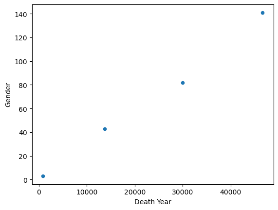

```python
plt.show()
```